# Project Overview

The project 0 is conducted to understand and setup python (Programming Language) and the necessary IDE (Integrated Development Environment) as a preparation for the learnings, practice and practical implementation of theoritical concepts for the 'Artificial Intelligence in Smart Grid' (ECE 563) course taught by Prof. Dr. Alexander J. Flueck. during the Spring semester of 2024 at Illinois Tech.

The Project 0 consists of four sub questions each addressing methods of implementations of logics and libraries disucssed during the lecture. They are as follows:

1. Setup and testing of the programming language and IDE.
2. Plotting a Sigmoid function for a set defined range of values.
3. Calculating the Mean and Standard Deviation for a range of pre-defined values then calculating and plotting the Gaussian Distribution function by appropriately marking and labelling wherever necessary.
4. Using Pandas library to import a given .csv (comma seperated values) file onto the python working directory and applying a given condition to filter, sort and display the output result.

The problem statements from the project 0 along with the code and the solutions are documented using Jupyter Notebook and are as follows.

### Problem statement 1

A screenshot of your computer showing your development environment, e.g., IPython shell, Jupyter Lab, Jupyter Notebook, Spyder, etc. with the following commands and their results displayed:

```python
import os
os.getlogin()
os.getcwd()
```

```
'/Users/Kashyap'
```

The solution above indicates that the setup is complete and the current working directory is displayed as the output.

### Problem Statement 2

Python code that creates a sigmoid plot from -6 to 6 using matplotlib. Be sure to include grid lines and a title on your plot. (Note: "%matplotlib tk" works for Tcl/Tk; "%matplotlib notebook" works for Jupyter; "%matplotlib inline" works for Jupyter and spyder. To connect to the default backend, use "%matplotlib" without any additional parameter). The plot showing your sigmoid function.

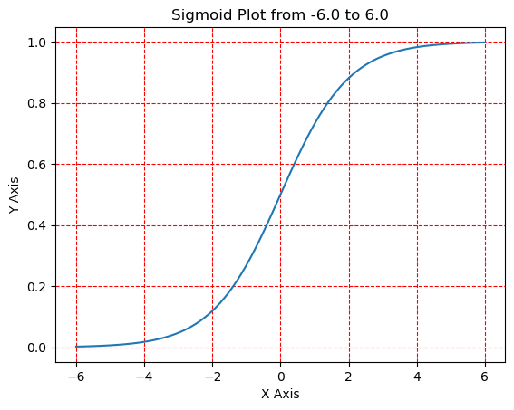

```python
import matplotlib.pyplot as plt
import numpy as np

#Range of sigmoid plot definition
r1 = -6
r2 = 6

#Generation of evenly spaced points within the range defined
x = np.linspace(r1,r2,100)

#Sigmoid function formula
y = 1/(1+np.exp(-x))

#Plot and plot properties
plt.plot(x, y)

plt.xlabel("X Axis")
plt.ylabel("Y Axis")
plt.title(f"Sigmoid Plot from {r1:.1f} to {r2:.1f}") #f-string is used to fetch data from the defined variables
plt.grid(color = 'Red', linestyle = '--')

plt.show()
```

The above solution to problem statement 2 displays with a blue curve which is the sigmoid function. The graph range is determined by the start and end point defined in the code as per the requirement from the problem statement.

### Problem Statement 3

Python code that creates two Gaussian probability density function plots with different standard deviation values. Be sure to include grid lines and a title on your plot. Also, be sure to use the marker attribute and the label attribute so that each curve is unique. Finally, include a legend on the plot that clearly explains the difference between the two curves shown on the same axes. To draw two curves on same axes in an interactive console/notebook, separate the plotting commands with a comma, i.e., plt.plot(x1,y1,marker="x"),plt.plot(x2,y2,marker="o"). The plot showing your two Gaussian functions on the same axes in a single figure.

```
Mean 1 = -120.0
Mean 2 = 463.5
Standard Deviation 1 = 274.46243755681695
Standard Deviation 2 = 393.50254128785497
```

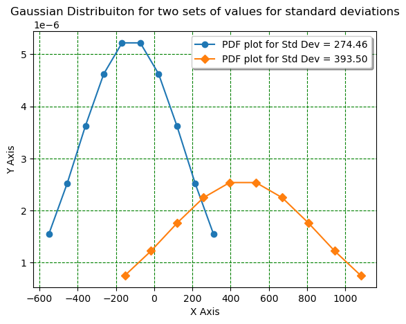

```python
import matplotlib.pyplot as plt
import numpy as np

#Generation of distribution range for two sets
x1 = np.linspace(-550, 310, 10)
x2 = np.linspace(-153,1080, 10)

#Generation of mean
m1 = np.mean(x1)
m2 = np.mean(x2)

#Generation of Standard Deviation
s1 = np.std(x1)
s2 = np.std(x2)

#Printing Mean and Standard Deviation for both the different sets of values to indicate the difference between them
print("Mean 1 =", m1)
print("Mean 2 =", m2)
print("Standard Deviation 1 =", s1)
print("Standard Deviation 2 =", s2)

#Gaussian Distribution formula for two sets of standard deviations
gd1 = 1 / (np.sqrt(2 * np.pi) * s1 ** 2) * np.exp(-((x1-m1) ** 2) / (2 * s1 ** 2))
gd2 = 1 / (np.sqrt(2 * np.pi) * s2 ** 2) * np.exp(-((x2-m2) ** 2) / (2 * s2 ** 2))

#Plot and plot properties
plt.plot(x1, gd1, marker='o', label=f'PDF plot for Std Dev = {s1:.2f}')
plt.plot(x2, gd2, marker='D', label=f'PDF plot for Std Dev = {s2:.2f}')

plt.title("Gaussian Distribuiton for two sets of values for standard deviations")
plt.grid(color = 'Green', linestyle = '--')
plt.xlabel("X Axis")
plt.ylabel("Y Axis")
plt.legend(shadow = True, loc = "upper right")


plt.show()
```

The above solution to the problem statement 3 is a console output showcasing the mean and standard distribution values for two ranges of data that is pre-defined. Added to this, the graph output is the plot of these two calculated Gaussian Distribution Functions which are differently colored and labelled in the legend as well to difference between them. The legend also contains the standard deviation of these two plots to identify the difference between them. Furthermore, the program also uses markers for the points along the curve (here circle and diamond is used) and the labelling of the axes with the title of the graph also included.

### Problem Statement 4

Python code that uses pandas to select and print 'Timestamp', 'VALPM:Magnitude', 'VBLPM:Magnitude', 'VCLPM:Magnitude' whenever the 'VCLPM:Magnitude' value is less than 199000 in the zipped CSV file of PMU data. The results from your Python code that selects and prints a subset of the PMU data above.

```python
import pandas as pd

#Reading the file from the database repository
df = pd.read_csv("//Users/Kashyap/Documents/Files/Academics/Institutions/Masters(USA)/IIT/Spring 2024 Semester/ECE563 (AI for Smart Grid)/Project 0/0.3/PMU01_140701.csv")

# Filter rows based on the condition
subset = df.loc[df["VCLPM:Magnitude"] < 199000, ["Timestamp", "VALPM:Magnitude", "VBLPM:Magnitude", "VCLPM:Magnitude"]]

# Save the resulting subset to a CSV file to manually verify the correctness of the condition application
subset.to_csv("//Users/Kashyap/Documents/Files/Academics/Institutions/Masters(USA)/IIT/Spring 2024 Semester/ECE563 (AI for Smart Grid)/Project 0/0.3/opsubset.csv", index=False)

# Print the resulting subset
print(subset)
```

```
                     Timestamp  VALPM:Magnitude  VBLPM:Magnitude  \
11315  2014/07/01 02:42:08.966      206117.2188      197712.6875
11476  2014/07/01 02:42:14.333      205979.9063      197424.2969
11477  2014/07/01 02:42:14.366      206323.2344      199758.8906
48926  2014/07/01 03:03:05.133      205595.3906      206446.8281
48927  2014/07/01 03:03:05.166      204551.6875      206062.2969
56064  2014/07/01 03:07:03.600      190640.2500      204277.0313
56065  2014/07/01 03:07:03.633      168283.0625      199415.5781
56066  2014/07/01 03:07:03.666      185916.1250      199470.5000

       VCLPM:Magnitude
11315      198948.6563
11476      198701.4688
11477      198509.2031
48926      198797.5938
48927      198179.6094
56064      198440.5313
56065      195103.4375
56066      196888.7188
```

The above solution represents the list of data from the columns defined as per the problem statement. The above list satisfies the given condition to check if VCLPM:Magnitude values are lesser than 199000 and prints the correspoding Timestamp, VALPM:Magnitude, VBLPM:Magnitude and VCLPM:Magnitude values. Additionally, to further verify the data manually using find and replace, there is a provision added to the code to save the result in an output .csv file.

# Conclusion

The project 0 has played a formative role to help understand the various issues that can appear during the setup of an environment in a system. It has also helped in understanding that the code tends to behave differently if not tested for robustness across IDEs in the same system. Learning and using python in general and its libraries such as matplotlib, numpy and pandas has indeed enabled confidence in the language and acclimitization towards the concepts.